None

# Продажи сетов и доптоваров за ноябрь 2024

# Описание исследования

**Цель исследования:** Ответить на бизнес-вопросы:

1. Оценить популярность доптоваров.
2. Оценить ЦА покупающих доптовары.

Все данные разделить по ГЕО (основные города Москва, Питер).

**ТЗ заказчика:**

1. расчет выручки и количества заказов по сетам и доптоварам,
2. расчет доли заказов и выручки сетов и доптоваров от общего количества продаж,
3. расчет среднего чека клиентов, покупающих сеты и доптовары без учета сетов и доптоваров,
4. расчет распределения сетов и доптоваров для каждого рациона. Поиск лидеров.
5. расчет доли заказов с рационами и доптоварами от общего количества товаров для новых/повторных клиентов. Посмотреть по линейкам.
6. для клиентов, заказывавших сеты и доптовары считаем дневной средний чек. Для Москвы определяем тех, у кого чек меньше 1242 рублей в категорию семейныйх людей, у кого меньше, в одиночек. Для питера берем чек 1187 рублей. Исключаем Баланс.
7. сравнить среднее количество дней питания в целом и для заказывающих сеты и допродажи.

**Ход исследования:**

- Написание SQL запросов на выгрузку данных https://food.vkusvill.ru:9191/superset/sqllab/?savedQueryId=196
- загрузка данных,
- чистка данных,
- создание категорий,
- написание кода, построение графиков,
- вывод.

**Выводы:**

Промежуточные выводы.

Развёрнутый отчёт с общими выводами.

# Загрузка и обработка данных

```python
import pandas as pd
import matplotlib.pyplot as plt
import numpy as np
import plotly.graph_objects as go
import plotly.io as pio
from sklearn.model_selection import train_test_split
from sklearn.tree import DecisionTreeClassifier
from sklearn import tree
import matplotlib.pyplot as plt
import matplotlib.dates as mdates
from scipy.stats import pearsonr
import statsmodels.api as sm
import seaborn as sns
from itertools import combinations
from collections import Counter
```

```python
data = pd.read_csv(r"C:\Users\ylka9\OneDrive\Рабочий стол\Analystic\VkusMeal\Aliya\Допродажи_сеты_ноябрь_24.csv", sep=';')
data.head()
```

|  | item_id | order_id | user_id | order_date | name | sum | days | city | order_flag |
| --- | --- | --- | --- | --- | --- | --- | --- | --- | --- |
| 0 | 153950 | 133627 | 1108840 | 01.11.2024 | Базовый 3 блюда | 4140 | 6 | moscow | 0 |
| 1 | 154069 | 133707 | 800127 | 01.11.2024 | Базовый 3 блюда | 4344 | 6 | moscow | 0 |
| 2 | 154071 | 133709 | 1095716 | 01.11.2024 | Базовый 3 блюда | 4140 | 6 | moscow | 0 |
| 3 | 154075 | 133713 | 1065391 | 01.11.2024 | Базовый 3 блюда | 9825 | 15 | moscow | 0 |
| 4 | 154097 | 133733 | 57011 | 02.11.2024 | Базовый 3 блюда | 9825 | 15 | moscow | 0 |

```python
data.info()
```

```
<class 'pandas.core.frame.DataFrame'>
RangeIndex: 2306 entries, 0 to 2305
Data columns (total 9 columns):
 #   Column      Non-Null Count  Dtype
---  ------      --------------  -----
 0   item_id     2306 non-null   int64
 1   order_id    2306 non-null   int64
 2   user_id     2306 non-null   int64
 3   order_date  2306 non-null   object
 4   name        2306 non-null   object
 5   sum         2306 non-null   int64
 6   days        2306 non-null   int64
 7   city        2306 non-null   object
 8   order_flag  2306 non-null   int64
dtypes: int64(6), object(3)
memory usage: 162.3+ KB
```

```python
data['order_date'] = pd.to_datetime(data['order_date'], format='%d.%m.%Y')
data.info()
```

```
<class 'pandas.core.frame.DataFrame'>
RangeIndex: 2306 entries, 0 to 2305
Data columns (total 9 columns):
 #   Column      Non-Null Count  Dtype
---  ------      --------------  -----
 0   item_id     2306 non-null   int64
 1   order_id    2306 non-null   int64
 2   user_id     2306 non-null   int64
 3   order_date  2306 non-null   datetime64[ns]
 4   name        2306 non-null   object
 5   sum         2306 non-null   int64
 6   days        2306 non-null   int64
 7   city        2306 non-null   object
 8   order_flag  2306 non-null   int64
dtypes: datetime64[ns](1), int64(6), object(2)
memory usage: 162.3+ KB
```

```python
# Приведение всех строковых значений к нижнему регистру
data = data.applymap(lambda x: x.lower() if isinstance(x, str) else x)
```

Создание дополнительного столбца для создания категорий для сетов и допродаж

```python
# Создаем пустой столбец 'category'
data['category'] = ''

# Словарь со значениями для категории "сеты"
sets_keywords = [
    'соки из вкусвилл',
    'смузи из вкусвилл',
    'фруктовые нарезки',
    'овощные нарезки',
    'десерт на каждый день',
    'круассан для настроения',
    'чиабатта к супу'
]

# Присваиваем категорию "сеты"
data.loc[data['name'].str.contains('|'.join(sets_keywords), case=False, na=False), 'category'] = 'сеты'

# Список ключевых слов для категории "допродажи"
upsell_keywords = [
    'на яблочном соке',
    'конфета',
    'чипсы',
    'снеки',
    'манго-апельсин',
    'напиток',
    'снек',
    'морская',
]

# Присваиваем категорию "допродажи"
data.loc[data['name'].str.contains('|'.join(upsell_keywords), case=False, na=False), 'category'] = 'допродажи'

# Присваиваем категорию "рационы" для всех записей, которые еще не имеют категории
data.loc[data['category'] == '', 'category'] = 'рационы'

# Выводим итоговый DataFrame
data.head()
```

|  | item_id | order_id | user_id | order_date | name | sum | days | city | order_flag | category |
| --- | --- | --- | --- | --- | --- | --- | --- | --- | --- | --- |
| 0 | 153950 | 133627 | 1108840 | 2024-11-01 | базовый 3 блюда | 4140 | 6 | moscow | 0 | рационы |
| 1 | 154069 | 133707 | 800127 | 2024-11-01 | базовый 3 блюда | 4344 | 6 | moscow | 0 | рационы |
| 2 | 154071 | 133709 | 1095716 | 2024-11-01 | базовый 3 блюда | 4140 | 6 | moscow | 0 | рационы |
| 3 | 154075 | 133713 | 1065391 | 2024-11-01 | базовый 3 блюда | 9825 | 15 | moscow | 0 | рационы |
| 4 | 154097 | 133733 | 57011 | 2024-11-02 | базовый 3 блюда | 9825 | 15 | moscow | 0 | рационы |

```python
data.groupby('city')['item_id'].count()
```

```
city
kazan                 26
moscow              1924
nizhny_novgorod       38
saint_petersburg     306
voronezh              12
Name: item_id, dtype: int64
```

Переименование рационов в единый формат

```python
# Определяем функцию для присвоения значений в столбец 'name'
def determine_ration(name):
    name = name.lower()  # Приводим к нижнему регистру для корректного сравнения
    if 'зц' in name:
        return 'зц'
    elif 'комбо' in name:
        return 'комбо'
    elif 'комб' in name:
        return 'комбо'
    elif 'баланс' in name:
        return 'баланс'
    elif 'ввг' in name or 'готовит' in name:
        return 'ввг'
    elif 'базовый' in name:
        return 'базовый'
    elif 'семейный' in name:
        return 'семейный'
    elif 'супер' in name:
        return 'супер'
    else:
        return name  # Возвращаем исходное значение, если ни одно условие не подошло

# Применяем функцию к столбцу 'name' и перезаписываем его
data['name'] = data['name'].apply(determine_ration)

# Выводим обновленный DataFrame
data.groupby('name')['item_id'].count()
```

```
name
базовый                                                  455
баланс                                                   552
ввг                                                      499
десерт на каждый день                                      5
зц                                                        66
комбо                                                    174
конфета протеиновая с кокосом                              2
конфета протеиновая с начинкой "фисташка"                  1
круассан для настроения                                    2
морская капуста хрустящая классическая, 5 г                4
напиток сокосодержащий "вода и сок" яблоко, 200 мл         1
напиток чайный "имбирный" с цедрой лимона                  2
овощные нарезки                                           21
семейный                                                 202
смузи "манго-апельсин", 250 мл                             4
смузи "морковь-ананас-банан" на яблочном соке, 250 мл      2
смузи из вкусвилл                                         28
снек овощной из батата                                     3
снеки хрустящие из картофеля свеклы и репы                 3
соки из вкусвилл                                          35
супер                                                    226
фруктовые нарезки                                         11
чиабатта к супу                                            4
чипсы протеиновые "сметана и зелень"                       4
Name: item_id, dtype: int64
```

# Исследование данных

### Расчет выручки и количества заказов по сетам и доптоварам

Смотрим сеты для Москвы

```python
# Фильтруем данные, оставляя только строки с category == "сеты"
msc_sets_data = data[data['category'] == 'сеты']
msc_sets_data = msc_sets_data[msc_sets_data['city'] == 'moscow']

# Создаем сводную таблицу
pivot_set_msc_table = msc_sets_data.pivot_table(
    index='name',
    values=['sum', 'days'],
    aggfunc={
        'sum': ['sum', 'count'],
        'days': 'sum'
    }
)

# Сброс индексов для лучшего отображения
pivot_set_msc_table = pivot_set_msc_table.reset_index()

# Переименование столбцов
pivot_set_msc_table.columns = ['название сета', 'количество дней питания', 'количество заказов', 'чистая выручка']

# Проверка результатов
pivot_set_msc_table.sort_values(by='чистая выручка', ascending=False)
```

|  | название сета | количество дней питания | количество заказов | чистая выручка |
| --- | --- | --- | --- | --- |
| 4 | соки из вкусвилл | 181 | 25 | 26900 |
| 2 | овощные нарезки | 112 | 10 | 16836 |
| 3 | смузи из вкусвилл | 132 | 20 | 16439 |
| 5 | фруктовые нарезки | 57 | 7 | 11400 |
| 0 | десерт на каждый день | 16 | 5 | 2400 |
| 1 | круассан для настроения | 8 | 2 | 1200 |
| 6 | чиабатта к супу | 20 | 3 | 548 |

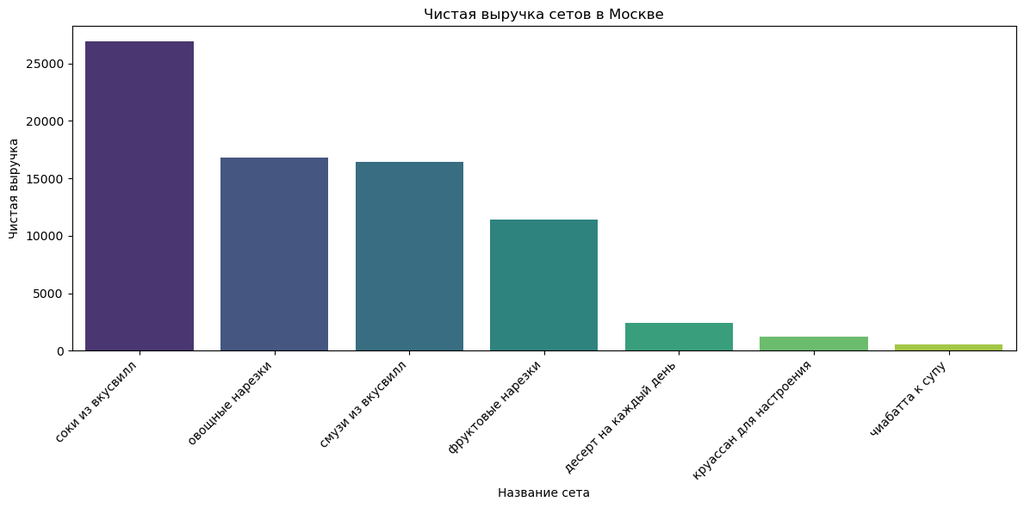

```python
# Сортируем сводную таблицу по чистой выручке по возрастанию
sorted_set_table = pivot_set_msc_table.sort_values(by='чистая выручка', ascending=False)

# Теперь строим графики на основе отсортированных данных

# 1. Столбчатая диаграмма для чистой выручки
plt.figure(figsize=(12, 6))
sns.barplot(x='название сета', y='чистая выручка', data=sorted_set_table, palette='viridis')
plt.xticks(rotation=45, ha='right')
plt.title('Чистая выручка сетов в Москве')
plt.xlabel('Название сета')
plt.ylabel('Чистая выручка')
plt.tight_layout()
plt.show()
```

Смотрим сеты для Питера

```python
# Фильтруем данные, оставляя только строки с category == "сеты"
sbp_sets_data = data[data['category'] == 'сеты']
sbp_sets_data = sbp_sets_data[sbp_sets_data['city'] == 'saint_petersburg']

# Создаем сводную таблицу
pivot_set_spb_table = sbp_sets_data.pivot_table(
    index='name',
    values=['sum', 'days'],
    aggfunc={
        'sum': ['sum', 'count'],
        'days': 'sum'
    }
)

# Сброс индексов для лучшего отображения
pivot_set_spb_table = pivot_set_spb_table.reset_index()

# Переименование столбцов
pivot_set_spb_table.columns = ['название сета', 'количество дней питания', 'количество заказов', 'чистая выручка']

# Проверка результатов
pivot_set_spb_table.sort_values(by='чистая выручка', ascending=False)
```

|  | название сета | количество дней питания | количество заказов | чистая выручка |
| --- | --- | --- | --- | --- |
| 2 | соки из вкусвилл | 70 | 9 | 9990 |
| 0 | овощные нарезки | 40 | 8 | 6300 |
| 3 | фруктовые нарезки | 24 | 4 | 4800 |
| 1 | смузи из вкусвилл | 32 | 7 | 4212 |
| 4 | чиабатта к супу | 6 | 1 | 174 |

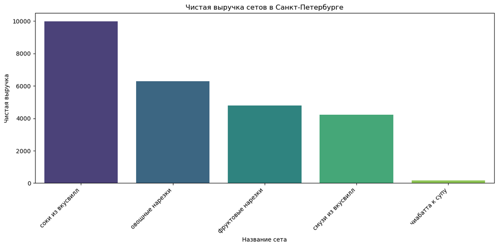

```python
# Сортируем сводную таблицу по чистой выручке по возрастанию
sorted_set_table = pivot_set_spb_table.sort_values(by='чистая выручка', ascending=False)

# Теперь строим графики на основе отсортированных данных

# 1. Столбчатая диаграмма для чистой выручки
plt.figure(figsize=(12, 6))
sns.barplot(x='название сета', y='чистая выручка', data=sorted_set_table, palette='viridis')
plt.xticks(rotation=45, ha='right')
plt.title('Чистая выручка сетов в Санкт-Петербурге')
plt.xlabel('Название сета')
plt.ylabel('Чистая выручка')
plt.tight_layout()
plt.show()
```

Смотрим допродажи для Москвы

```python
# Фильтруем данные, оставляя только строки с category == "сеты"
msc_dops_data = data[data['category'] == 'допродажи']
msc_dops_data = msc_dops_data[msc_dops_data['city'] == 'moscow']

# Создаем сводную таблицу
pivot_dop_msc_table = msc_dops_data.pivot_table(
    index='name',
    values=['sum', 'days'],
    aggfunc={
        'sum': ['sum', 'count'],
        'days': 'sum'
    }
)

# Сброс индексов для лучшего отображения
pivot_dop_msc_table = pivot_dop_msc_table.reset_index()

# Переименование столбцов
pivot_dop_msc_table.columns = ['название сета', 'количество дней питания', 'количество заказов', 'чистая выручка']

# Проверка результатов
pivot_dop_msc_table.sort_values(by='чистая выручка', ascending=False)
```

|  | название сета | количество дней питания | количество заказов | чистая выручка |
| --- | --- | --- | --- | --- |
| 7 | чипсы протеиновые "сметана и зелень" | 3 | 3 | 796 |
| 3 | смузи "манго-апельсин", 250 мл | 4 | 4 | 614 |
| 5 | снек овощной из батата | 3 | 3 | 378 |
| 4 | смузи "морковь-ананас-банан" на яблочном соке,... | 2 | 2 | 318 |
| 0 | конфета протеиновая с кокосом | 2 | 2 | 297 |
| 6 | снеки хрустящие из картофеля свеклы и репы | 3 | 3 | 279 |
| 1 | морская капуста хрустящая классическая, 5 г | 3 | 3 | 266 |
| 2 | напиток чайный "имбирный" с цедрой лимона | 1 | 1 | 99 |

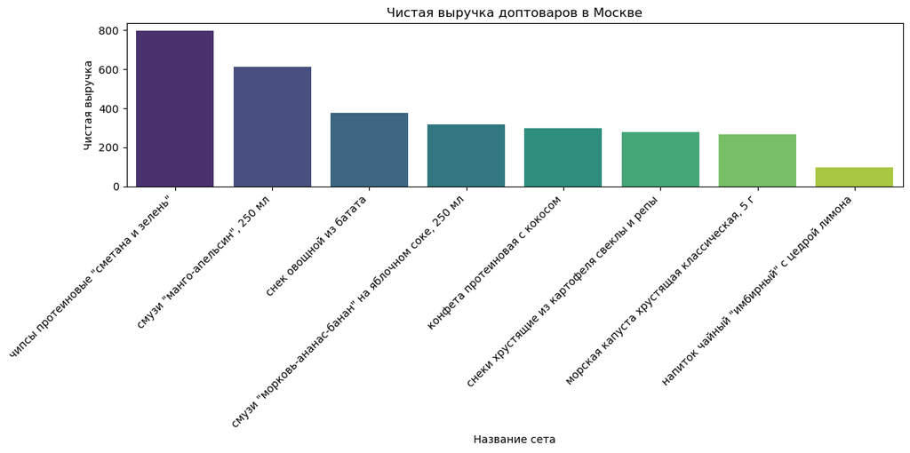

```python
# Сортируем сводную таблицу по чистой выручке по возрастанию
sorted_set_table = pivot_dop_msc_table.sort_values(by='чистая выручка', ascending=False)

# Теперь строим графики на основе отсортированных данных

# 1. Столбчатая диаграмма для чистой выручки
plt.figure(figsize=(12, 6))
sns.barplot(x='название сета', y='чистая выручка', data=sorted_set_table, palette='viridis')
plt.xticks(rotation=45, ha='right')
plt.title('Чистая выручка доптоваров в Москве')
plt.xlabel('Название сета')
plt.ylabel('Чистая выручка')
plt.tight_layout()
plt.show()
```

Смотрим допродажи для Питера

```python
# Фильтруем данные, оставляя только строки с category == "сеты"
sbp_dops_data = data[data['category'] == 'допродажи']
sbp_dops_data = sbp_dops_data[sbp_dops_data['city'] == 'saint_petersburg']

# Создаем сводную таблицу
pivot_dop_spb_table = sbp_dops_data.pivot_table(
    index='name',
    values=['sum', 'days'],
    aggfunc={
        'sum': ['sum', 'count'],
        'days': 'sum'
    }
)

# Сброс индексов для лучшего отображения
pivot_dop_spb_table = pivot_dop_spb_table.reset_index()

# Переименование столбцов
pivot_dop_spb_table.columns = ['название сета', 'количество дней питания', 'количество заказов', 'чистая выручка']

# Проверка результатов
pivot_dop_spb_table.sort_values(by='чистая выручка', ascending=False)
```

|  | название сета | количество дней питания | количество заказов | чистая выручка |
| --- | --- | --- | --- | --- |
| 4 | чипсы протеиновые "сметана и зелень" | 1 | 1 | 199 |
| 0 | конфета протеиновая с начинкой "фисташка" | 1 | 1 | 99 |
| 1 | морская капуста хрустящая классическая, 5 г | 1 | 1 | 99 |
| 3 | напиток чайный "имбирный" с цедрой лимона | 1 | 1 | 99 |
| 2 | напиток сокосодержащий "вода и сок" яблоко, 20... | 1 | 1 | 49 |

[figure not shown]

```python
# Сортируем сводную таблицу по чистой выручке по возрастанию
sorted_set_table = pivot_dop_spb_table.sort_values(by='чистая выручка', ascending=False)

# Теперь строим графики на основе отсортированных данных

# 1. Столбчатая диаграмма для чистой выручки
plt.figure(figsize=(12, 6))
sns.barplot(x='название сета', y='чистая выручка', data=sorted_set_table, palette='viridis')
plt.xticks(rotation=45, ha='right')
plt.title('Чистая выручка доптоваров в Москве')
plt.xlabel('Название сета')
plt.ylabel('Чистая выручка')
plt.tight_layout()
plt.show()
```

### Расчет доли заказов и выручки сетов и доптоваров от общего количества продаж

Доля выручки сетов и доптоваров для Москвы и Питера

```python
# Создание сводной таблицы для Москвы
moscow_data = data[data['city'] == 'moscow']
moscow_pivot_table = moscow_data.pivot_table(
    index='category',
    values='sum',
    aggfunc='sum'
).reset_index()
moscow_pivot_table.columns = ['категория', 'выручка']

# Вычисление общей выручки для Москвы
moscow_total_revenue = moscow_pivot_table['выручка'].sum()

# Вычисление доли выручки каждой категории для Москвы
moscow_pivot_table['доля'] = moscow_pivot_table['выручка'] / moscow_total_revenue
moscow_pivot_table['доля'] = moscow_pivot_table['доля'].apply(lambda x: f'{x:.2%}')

# Стилизация таблицы
styled_moscow_table = moscow_pivot_table.style \
    .set_table_attributes('style="font-size: 14px; margin: 20px 0; border-collapse: collapse;"') \
    .set_caption("Сводная таблица выручки по категориям для Москвы") \
    .set_properties(**{'text-align': 'left', 'border': '1px solid black'}) \
# Отображаем результат
styled_moscow_table
```

Сводная таблица выручки по категориям для Москвы

|  | категория | выручка | доля |
| --- | --- | --- | --- |
| 0 | допродажи | 3047 | 0.01% |
| 1 | рационы | 20369017 | 99.61% |
| 2 | сеты | 75723 | 0.37% |

```python
# Создание сводной таблицы для Санкт-Петербурга
spb_data = data[data['city'] == 'saint_petersburg']
spb_pivot_table = spb_data.pivot_table(
    index='category',
    values='sum',
    aggfunc='sum'
).reset_index()
spb_pivot_table.columns = ['категория', 'выручка']

# Вычисление общей выручки для Санкт-Петербурга
spb_total_revenue = spb_pivot_table['выручка'].sum()

# Вычисление доли выручки каждой категории для Санкт-Петербурга
spb_pivot_table['доля'] = spb_pivot_table['выручка'] / spb_total_revenue
spb_pivot_table['доля'] = spb_pivot_table['доля'].apply(lambda x: f'{x:.2%}')

# Стилизация таблицы
styled_spb_table = spb_pivot_table.style \
    .set_table_attributes('style="font-size: 14px; margin: 20px 0; border-collapse: collapse;"') \
    .set_caption("Сводная таблица выручки по категориям для Санкт-Петербурга") \
    .set_properties(**{'text-align': 'left', 'border': '1px solid black'}) \

# Отображение результата для Санкт-Петербурга
styled_spb_table
```

Сводная таблица выручки по категориям для Санкт-Петербурга

|  | категория | выручка | доля |
| --- | --- | --- | --- |
| 0 | допродажи | 545 | 0.02% |
| 1 | рационы | 2753489 | 99.06% |
| 2 | сеты | 25476 | 0.92% |

Доля количества продаж сетов и доптоваров для Москвы и Питера

```python
# Создание сводной таблицы для Москвы
moscow_data = data[data['city'] == 'moscow']
moscow_pivot_table = moscow_data.pivot_table(
    index='category',
    values='sum',
    aggfunc='count'
).reset_index()
moscow_pivot_table.columns = ['категория', 'кол-во продаж']

# Вычисление общей выручки для Москвы
moscow_total_revenue = moscow_pivot_table['кол-во продаж'].sum()

# Вычисление доли выручки каждой категории для Москвы
moscow_pivot_table['доля'] = moscow_pivot_table['кол-во продаж'] / moscow_total_revenue
moscow_pivot_table['доля'] = moscow_pivot_table['доля'].apply(lambda x: f'{x:.2%}')

# Стилизация таблицы
styled_moscow_table = moscow_pivot_table.style \
    .set_table_attributes('style="font-size: 14px; margin: 20px 0; border-collapse: collapse;"') \
    .set_caption("Сводная таблица кол-ва продаж по категориям для Москвы") \
    .set_properties(**{'text-align': 'left', 'border': '1px solid black'}) \
# Отображаем результат
styled_moscow_table
```

Сводная таблица кол-ва продаж по категориям для Москвы

|  | категория | кол-во продаж | доля |
| --- | --- | --- | --- |
| 0 | допродажи | 21 | 1.09% |
| 1 | рационы | 1831 | 95.17% |
| 2 | сеты | 72 | 3.74% |

```python
# Создание сводной таблицы для Санкт-Петербурга
spb_data = data[data['city'] == 'saint_petersburg']
spb_pivot_table = spb_data.pivot_table(
    index='category',
    values='sum',
    aggfunc='count'
).reset_index()
spb_pivot_table.columns = ['категория', 'количество продаж']

# Вычисление общей выручки для Санкт-Петербурга
spb_total_revenue = spb_pivot_table['количество продаж'].sum()

# Вычисление доли выручки каждой категории для Санкт-Петербурга
spb_pivot_table['доля'] = spb_pivot_table['количество продаж'] / spb_total_revenue
spb_pivot_table['доля'] = spb_pivot_table['доля'].apply(lambda x: f'{x:.2%}')

# Стилизация таблицы
styled_spb_table = spb_pivot_table.style \
    .set_table_attributes('style="font-size: 14px; margin: 20px 0; border-collapse: collapse;"') \
    .set_caption("Сводная таблица кол-ва продаж по категориям для Питера") \
    .set_properties(**{'text-align': 'left', 'border': '1px solid black'}) \
# Отображаем результат
styled_spb_table
```

Сводная таблица кол-ва продаж по категориям для Питера

|  | категория | количество продаж | доля |
| --- | --- | --- | --- |
| 0 | допродажи | 5 | 1.63% |
| 1 | рационы | 272 | 88.89% |
| 2 | сеты | 29 | 9.48% |

### Расчет среднего чека клиентов, покупающих сеты и доптовары без учета сетов и доптоваров

Создали датафрейм с заказами и сетами/доптоварами к этим заказам.

*Т.к. сумма продаж по сетам и доптоарам маленькая, то убиать из для расчета среднего чека я не стала

```python
# Создаем пустой DataFrame для хранения пользователей с определенными категориями
users_with_dops = pd.DataFrame(columns=data.columns)

# Получаем уникальные user_id для категорий "рационы" и "сеты"/"допродажи"
unique_users = data['user_id'].unique()

# Проходим по каждому уникальному пользователю
for user in unique_users:
    # Получаем данные конкретного пользователя
    user_data = data[data['user_id'] == user]

    # Проверяем наличие категории "рацион"
    has_diet = 'рационы' in user_data['category'].values

    # Проверка на наличие нужных категорий
    has_other_categories = any(cat in user_data['category'].values for cat in ['сеты', 'допродажи'])

    # Если пользователь делает заказы в обеих категориях, добавляем строки в users_with_dops
    if has_diet and has_other_categories:
        users_with_dops = pd.concat([users_with_dops, user_data])

# Сбрасываем индексы для удобства (по желанию)
users_with_dops.reset_index(drop=True, inplace=True)

# Выводим результаты
users_with_dops.sort_values(by='user_id', ascending=False).head(10)
```

|  | item_id | order_id | user_id | order_date | name | sum | days | city | order_flag | category |
| --- | --- | --- | --- | --- | --- | --- | --- | --- | --- | --- |
| 150 | 157213 | 136176 | 1134875 | 2024-11-27 | базовый | 13160 | 14 | voronezh | 0 | рационы |
| 151 | 157214 | 136176 | 1134875 | 2024-11-27 | смузи из вкусвилл | 1820 | 14 | voronezh | 0 | сеты |
| 169 | 157091 | 136073 | 1134484 | 2024-11-25 | смузи из вкусвилл | 260 | 2 | moscow | 0 | сеты |
| 167 | 157089 | 136073 | 1134484 | 2024-11-25 | комбо | 3180 | 2 | moscow | 0 | рационы |
| 168 | 157090 | 136073 | 1134484 | 2024-11-25 | смузи из вкусвилл | 260 | 2 | moscow | 0 | сеты |
| 249 | 156944 | 135944 | 1133297 | 2024-11-24 | фруктовые нарезки | 400 | 2 | moscow | 0 | сеты |
| 248 | 156943 | 135944 | 1133297 | 2024-11-24 | семейный | 2800 | 2 | moscow | 0 | рационы |
| 165 | 156915 | 135918 | 1133132 | 2024-11-24 | комбо | 10896 | 8 | moscow | 0 | рационы |
| 166 | 156916 | 135918 | 1133132 | 2024-11-24 | овощные нарезки | 1200 | 8 | moscow | 0 | сеты |
| 27 | 157261 | 136219 | 1132246 | 2024-11-27 | соки из вкусвилл | 600 | 4 | moscow | 1 | сеты |

```python
users_with_dops.info()
```

```
<class 'pandas.core.frame.DataFrame'>
RangeIndex: 285 entries, 0 to 284
Data columns (total 10 columns):
 #   Column      Non-Null Count  Dtype
---  ------      --------------  -----
 0   item_id     285 non-null    object
 1   order_id    285 non-null    object
 2   user_id     285 non-null    object
 3   order_date  285 non-null    datetime64[ns]
 4   name        285 non-null    object
 5   sum         285 non-null    object
 6   days        285 non-null    object
 7   city        285 non-null    object
 8   order_flag  285 non-null    object
 9   category    285 non-null    object
dtypes: datetime64[ns](1), object(9)
memory usage: 22.4+ KB
```

```python
users_with_dops['sum'] = users_with_dops['sum'].astype(int)
```

Средний чек по линейкам Москва

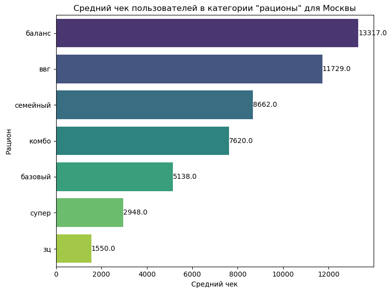

```python
users_with_dops_avg_check_msc = users_with_dops[users_with_dops['category'] == 'рационы']
users_with_dops_avg_check_msc = users_with_dops_avg_check_msc[users_with_dops_avg_check_msc['city'] == 'moscow']
users_with_dops_avg_check_msc = users_with_dops_avg_check_msc.groupby('name')['sum'].mean().reset_index()
users_with_dops_avg_check_msc['sum'] = users_with_dops_avg_check_msc['sum'].round()
users_with_dops_avg_check_msc = users_with_dops_avg_check_msc.sort_values(by='sum', ascending=False)

# Предполагаем, что users_with_dops_avg_check_msc уже создан и содержит необходимые данные
plt.figure(figsize=(8, 6))
sns.barplot(x='sum', y='name', data=users_with_dops_avg_check_msc, palette='viridis');

# Добавление заголовка и меток осей
plt.title('Средний чек пользователей в категории "рационы" для Москвы', fontsize=12)
plt.xlabel('Средний чек', fontsize=10)
plt.ylabel('Рацион', fontsize=10)

# Показ значений средних чеков на графике
for index, value in enumerate(users_with_dops_avg_check_msc['sum']):
    plt.text(value + 0.1, index, f'{value}', va='center', fontsize=10)

# Отображение графика
plt.tight_layout()
plt.show()
```

Общий средний чек Москва

```python
users_with_dops_avg_check_msc['sum'].mean().round()
```

```
7281.0
```

Средний чек без баланса Москва

```python
# Фильтрация строк, где name не содержит слово 'баланс'
filtered_balance_data = users_with_dops_avg_check_msc[~users_with_dops_avg_check_msc['name'].str.contains('баланс', na=False)]
filtered_balance_data['sum'].mean()
```

```
6274.5
```

Средний чек по линейкам Питер

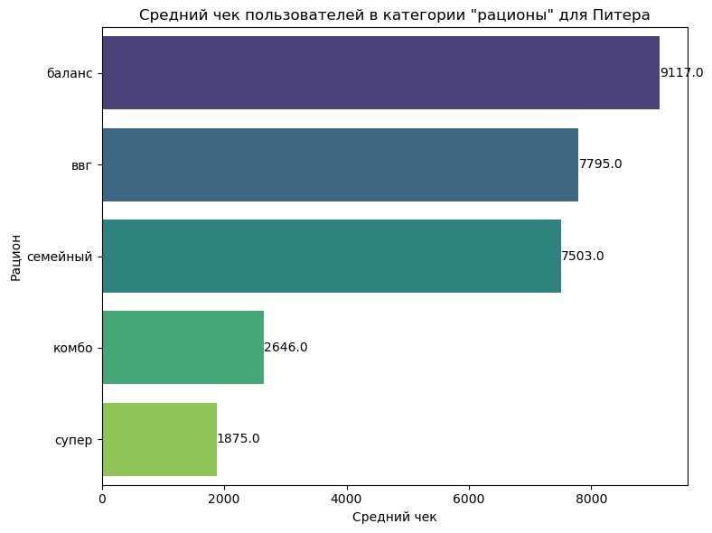

```python
users_with_dops_avg_check_spb = users_with_dops[users_with_dops['category'] == 'рационы']
users_with_dops_avg_check_spb = users_with_dops_avg_check_spb[users_with_dops_avg_check_spb['city'] == 'saint_petersburg']
users_with_dops_avg_check_spb = users_with_dops_avg_check_spb.groupby('name')['sum'].mean().reset_index()
users_with_dops_avg_check_spb['sum'] = users_with_dops_avg_check_spb['sum'].round()
users_with_dops_avg_check_spb = users_with_dops_avg_check_spb.sort_values(by='sum', ascending=False)


# Предполагаем, что users_with_dops_avg_check_msc уже создан и содержит необходимые данные
plt.figure(figsize=(8, 6))
sns.barplot(x='sum', y='name', data=users_with_dops_avg_check_spb, palette='viridis');

# Добавление заголовка и меток осей
plt.title('Средний чек пользователей в категории "рационы" для Питера', fontsize=12)
plt.xlabel('Средний чек', fontsize=10)
plt.ylabel('Рацион', fontsize=10)

# Показ значений средних чеков на графике
for index, value in enumerate(users_with_dops_avg_check_spb['sum']):
    plt.text(value + 0.6, index, f'{value}', va='center', fontsize=10)

# Отображение графика
plt.tight_layout()
plt.show()
```

Общий средний чек Питер

```python
users_with_dops_avg_check_spb['sum'].mean()
```

```
5787.2
```

Средний чек без баланса Питер

```python
# Фильтрация строк, где name не содержит слово 'баланс'
filtered_balance_data_spb = users_with_dops_avg_check_spb[~users_with_dops_avg_check_spb['name'].str.contains('баланс', na=False)]
filtered_balance_data_spb['sum'].mean()
```

```
4954.75
```

### Расчет распределения сетов и доптоваров для каждого рациона. Поиск лидеров

```python
# Группировка по 'order_id' и 'order_date', подсчет числа заказов
grouped = data.groupby(['order_id', 'order_date']).size().reset_index(name='count')

# Фильтрация групп с количеством заказов 2 и более
filtered_orders = grouped[grouped['count'] >= 2]

# Слияние исходного DataFrame с отфильтрованными заказами для получения полной информации
result_df = data.merge(filtered_orders[['order_id', 'order_date']], on=['order_id', 'order_date'])

# Вывод результата
result_df
```

|  | item_id | order_id | user_id | order_date | name | sum | days | city | order_flag | category |
| --- | --- | --- | --- | --- | --- | --- | --- | --- | --- | --- |
| 0 | 154131 | 133767 | 33515 | 2024-11-02 | базовый | 4410 | 6 | moscow | 0 | рационы |
| 1 | 154132 | 133767 | 33515 | 2024-11-02 | базовый | 5250 | 6 | moscow | 0 | рационы |
| 2 | 154136 | 133771 | 975084 | 2024-11-02 | базовый | 4140 | 6 | moscow | 0 | рационы |
| 3 | 154137 | 133771 | 975084 | 2024-11-02 | базовый | 4980 | 6 | moscow | 0 | рационы |
| 4 | 154138 | 133771 | 975084 | 2024-11-02 | базовый | 4980 | 6 | moscow | 0 | рационы |
| ... | ... | ... | ... | ... | ... | ... | ... | ... | ... | ... |
| 404 | 157245 | 136204 | 938321 | 2024-11-27 | ввг | 37260 | 30 | saint_petersburg | 0 | рационы |
| 405 | 156931 | 135932 | 1058732 | 2024-11-24 | ввг | 7760 | 8 | saint_petersburg | 0 | рационы |
| 406 | 156930 | 135932 | 1058732 | 2024-11-24 | супер | 1890 | 2 | saint_petersburg | 0 | рационы |
| 407 | 155977 | 135187 | 82976 | 2024-11-18 | супер | 1734 | 2 | saint_petersburg | 0 | рационы |
| 408 | 155978 | 135187 | 82976 | 2024-11-18 | супер | 1734 | 2 | saint_petersburg | 0 | рационы |

409 rows × 10 columns

Оставляем только комбинации с рационами

```python
# Группировка и фильтрация
filtered = (result_df.groupby(['order_id', 'order_date'])['category']
            .nunique()
            .reset_index(name='unique_categories_count'))

# Оставляем только те записи, где количество уникальных категорий больше 1
filtered = filtered[filtered['unique_categories_count'] > 1]

# Объединение с исходным DataFrame для получения нужных строк
final_result = pd.merge(result_df, filtered[['order_id', 'order_date']],
                         on=['order_id', 'order_date'])

# Вывод финального результата
final_result.head(10)
```

|  | item_id | order_id | user_id | order_date | name | sum | days | city | order_flag | category |
| --- | --- | --- | --- | --- | --- | --- | --- | --- | --- | --- |
| 0 | 154454 | 134063 | 1082363 | 2024-11-05 | базовый | 4140 | 6 | moscow | 0 | рационы |
| 1 | 154455 | 134063 | 1082363 | 2024-11-05 | соки из вкусвилл | 900 | 6 | moscow | 0 | сеты |
| 2 | 155187 | 134612 | 888318 | 2024-11-11 | базовый | 8355 | 15 | moscow | 0 | рационы |
| 3 | 155188 | 134612 | 888318 | 2024-11-11 | овощные нарезки | 1920 | 15 | moscow | 0 | сеты |
| 4 | 155189 | 134612 | 888318 | 2024-11-11 | фруктовые нарезки | 2550 | 15 | moscow | 0 | сеты |
| 5 | 155892 | 135108 | 1095316 | 2024-11-17 | базовый | 4140 | 6 | moscow | 1 | рационы |
| 6 | 155893 | 135108 | 1095316 | 2024-11-17 | смузи "манго-апельсин", 250 мл | 159 | 1 | moscow | 1 | допродажи |
| 7 | 155894 | 135108 | 1095316 | 2024-11-17 | смузи "морковь-ананас-банан" на яблочном соке,... | 159 | 1 | moscow | 1 | допродажи |
| 8 | 154234 | 133861 | 1098171 | 2024-11-03 | базовый | 4668 | 6 | moscow | 0 | рационы |
| 9 | 154235 | 133861 | 1098171 | 2024-11-03 | морская капуста хрустящая классическая, 5 г | 89 | 1 | moscow | 0 | допродажи |

Найдем топ комбинаций для Москвы

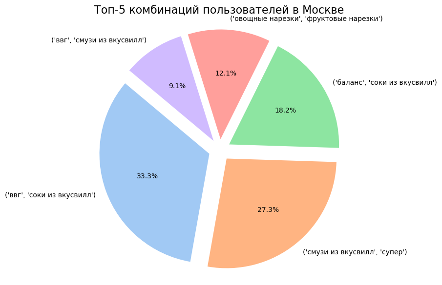

```python
# Шаг 1: Фильтруем данные для Москвы
msc_combinations = final_result.query('city == "moscow"')

# Шаг 2: Группируем данные и собираем все name в списки
msc_combinations = msc_combinations.groupby(['order_id', 'order_date'])['name'].apply(list).reset_index()

# Шаг 3: Функция для подсчета комбинаций
def count_combinations(names):
    combs = combinations(sorted(set(names)), 2)  # Генерируем все возможные комбинации 2-х элементов
    return Counter(combs)

# Шаг 4: Применяем функцию к каждой группе и считаем комбинации
msc_combinations['combinations'] = msc_combinations['name'].apply(count_combinations)

# Шаг 5: Объединяем результаты в один общий счетчик
total_combinations = Counter()
for count in msc_combinations['combinations']:
    total_combinations.update(count)

# Шаг 6: Преобразуем счетчик в DataFrame для удобства
msc_combinations_data = pd.DataFrame(total_combinations.items(), columns=['combination', 'count'])

# Выводим итоговые комбинации, отсортированные по убыванию
result = msc_combinations_data.sort_values(by='count', ascending=False)

# Фильтруем топ-5 комбинаций
top_5_combinations = result.head(5)

# Извлекаем данные для диаграммы
labels = top_5_combinations['combination'].astype(str)  # Преобразуем комбинации в строку для меток
sizes = top_5_combinations['count']  # Количество для каждой комбинации

# Настройка диаграммы пирога
plt.figure(figsize=(10, 7))
plt.pie(sizes, labels=labels, autopct='%1.1f%%', startangle=140, colors=sns.color_palette('pastel'), explode=[0.1]*len(labels))

# Заголовок диаграммы
plt.title('Топ-5 комбинаций пользователей в Москве', fontsize=16)
plt.axis('equal')  # Гарантирует, что пирог будет круговым

# Отображение диаграммы
plt.show()
```

Найдем топ комбинаций для Питера

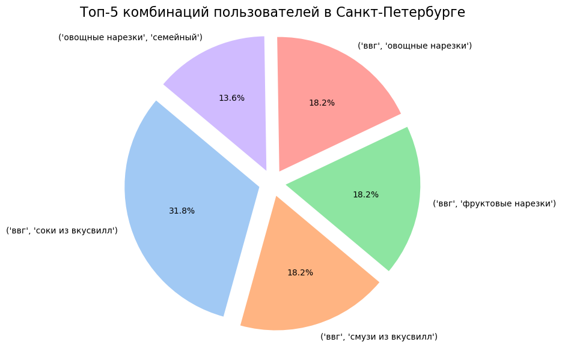

```python
import pandas as pd
import matplotlib.pyplot as plt
from collections import Counter
from itertools import combinations
import seaborn as sns

# Шаг 1: Фильтруем данные для Санкт-Петербурга
spb_combinations = final_result.query('city == "saint_petersburg"')

# Шаг 2: Группируем данные и собираем все name в списки
spb_combinations = spb_combinations.groupby(['order_id', 'order_date'])['name'].apply(list).reset_index()

# Шаг 3: Функция для подсчета комбинаций
def count_combinations(names):
    combs = combinations(sorted(set(names)), 2)  # Генерируем все возможные комбинации 2-х элементов
    return Counter(combs)

# Шаг 4: Применяем функцию к каждой группе и считаем комбинации
spb_combinations['combinations'] = spb_combinations['name'].apply(count_combinations)

# Шаг 5: Объединяем результаты в один общий счетчик
total_combinations = Counter()
for count in spb_combinations['combinations']:
    total_combinations.update(count)

# Шаг 6: Преобразуем счетчик в DataFrame для удобства
spb_combinations_data = pd.DataFrame(total_combinations.items(), columns=['combination', 'count'])

# Шаг 7: Выводим итоговые комбинации, отсортированные по убыванию
sorted_spb_combinations_data = spb_combinations_data.sort_values(by='count', ascending=False)

# Шаг 8: Создаем круговую диаграмму для топ-5 комбинаций
top_5_spb_combinations = sorted_spb_combinations_data.head(5)

# Извлекаем данные для диаграммы
labels = top_5_spb_combinations['combination'].astype(str)  # Преобразуем комбинации в строку для меток
sizes = top_5_spb_combinations['count']  # Количество для каждой комбинации

# Настройка диаграммы пирога
plt.figure(figsize=(10, 7))
plt.pie(sizes, labels=labels, autopct='%1.1f%%', startangle=140, colors=sns.color_palette('pastel'), explode=[0.1]*len(labels))

# Заголовок диаграммы
plt.title('Топ-5 комбинаций пользователей в Санкт-Петербурге', fontsize=16)
plt.axis('equal')  # Гарантирует, что пирог будет круговым

# Отображение диаграммы
plt.show()
```

### Расчет доли заказов с рационами и доптоварами от общего количества заказов для новых/повторных клиентов

Создание датафрейма с новыми клиентами и их комбинациями для Москвы

```python
msc_new_clients = data.query('city == "moscow" & order_flag == 0')

# Шаг 1: Группируем данные по user_id и категории
msc_clients_categories = msc_new_clients.groupby('user_id')['category'].nunique().reset_index()

# Шаг 2: Добавляем новый столбец для флагов
def set_combo_flag(row):
    if row['category'] > 1:
        return "есть комбинации"  # Если более одной категории
    else:
        return "нет комбинаций"  # Если одна категория

msc_clients_categories['if_combo'] = msc_clients_categories.apply(set_combo_flag, axis=1)

# Шаг 3: Объединяем с оригинальным DataFrame
msc_new_clients = msc_new_clients.merge(msc_clients_categories[['user_id', 'if_combo']], on='user_id', how='left')

# Теперь msc_new_clients содержит новый столбец if_combo
msc_new_clients = msc_new_clients.sort_values(by='order_id')
msc_new_clients.tail(10)
```

|  | item_id | order_id | user_id | order_date | name | sum | days | city | order_flag | category | if_combo |
| --- | --- | --- | --- | --- | --- | --- | --- | --- | --- | --- | --- |
| 974 | 157283 | 136235 | 1035213 | 2024-11-27 | морская капуста хрустящая классическая, 5 г | 88 | 1 | moscow | 0 | допродажи | есть комбинации |
| 1201 | 157286 | 136238 | 187354 | 2024-11-27 | семейный | 46650 | 30 | moscow | 0 | рационы | нет комбинаций |
| 1077 | 157293 | 136245 | 912800 | 2024-11-27 | супер | 2988 | 3 | moscow | 0 | рационы | нет комбинаций |
| 457 | 157297 | 136248 | 374699 | 2024-11-27 | баланс | 28416 | 16 | moscow | 0 | рационы | нет комбинаций |
| 273 | 157298 | 136249 | 1134952 | 2024-11-27 | базовый | 3150 | 3 | moscow | 0 | рационы | нет комбинаций |
| 1078 | 157300 | 136251 | 807284 | 2024-11-27 | супер | 2850 | 3 | moscow | 0 | рационы | нет комбинаций |
| 1079 | 157301 | 136252 | 640038 | 2024-11-27 | супер | 2988 | 3 | moscow | 0 | рационы | есть комбинации |
| 1219 | 157302 | 136252 | 640038 | 2024-11-27 | смузи из вкусвилл | 390 | 3 | moscow | 0 | сеты | есть комбинации |
| 672 | 157304 | 136254 | 1065723 | 2024-11-27 | ввг | 25950 | 30 | moscow | 0 | рационы | нет комбинаций |
| 106 | 157307 | 136257 | 944384 | 2024-11-27 | базовый | 4140 | 6 | moscow | 0 | рационы | нет комбинаций |

Соотношений комбинаций новых клиентов Москва

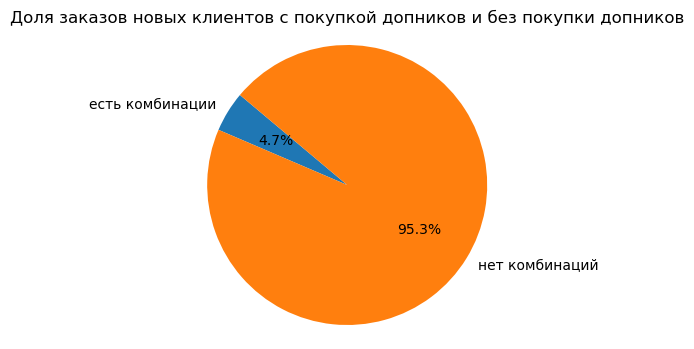

```python
# Шаг 2: Группируем по if_combo и считаем количество уникальных заказов
msc_new_order_counts = msc_new_clients.groupby('if_combo')['order_id'].nunique().reset_index()
msc_new_order_counts.columns = ['if_combo', 'unique_order_count']

# Шаг 3: Общая сумма уникальных заказов
total_unique_orders = msc_new_clients['order_id'].nunique()

# Шаг 4: Вычисляем долю для каждой категории
msc_new_order_counts['proportion'] = msc_new_order_counts['unique_order_count'] / total_unique_orders

# Шаг 1: Настройка круговой диаграммы
plt.figure(figsize=(6, 4))
plt.pie(msc_new_order_counts['proportion'], labels=msc_new_order_counts['if_combo'], autopct='%1.1f%%', startangle=140)

# Шаг 2: Добавление заголовка
plt.title('Доля заказов новых клиентов с покупкой допников и без покупки допников в Москве')

# Шаг 3: Отображение диаграммы
plt.axis('equal')  # Создает круговую диаграмму
plt.show()
```

Соотношений комбинаций новых клиентов Москва по линейкам

```python
# Фильтруем данные по 'category' == "рационы"
msc_rat_clients = msc_new_clients[msc_new_clients['category'] == 'рационы'].copy()

# Группируем по 'name' и 'if_combo', чтобы сосчитать уникальных пользователей
msc_rat_combo_counts = msc_rat_clients.groupby(['name', 'if_combo'])['user_id'].nunique().reset_index()

# Пивотируем таблицу для лучшей видимости соотношений
msc_rat_combo_pivot = msc_rat_combo_counts.pivot(index='name', columns='if_combo', values='user_id').fillna(0)

# Рассчитываем общее количество пользователей с комбинациями и без
msc_rat_combo_pivot['total'] = msc_rat_combo_pivot.sum(axis=1)

# Рассчитываем соотношение
msc_rat_combo_pivot['ratio_with_combo'] = msc_rat_combo_pivot.get('есть комбинации', 0) / msc_rat_combo_pivot['total'] * 100
msc_rat_combo_pivot['ratio_without_combo'] = msc_rat_combo_pivot.get('нет комбинаций', 0) / msc_rat_combo_pivot['total'] * 100

# Смотрим результат
msc_rat_combo_pivot[['есть комбинации', 'нет комбинаций', 'total', 'ratio_with_combo', 'ratio_without_combo']]
```

| if_combo name | есть комбинации | нет комбинаций | total | ratio_with_combo | ratio_without_combo |
| --- | --- | --- | --- | --- | --- |
| базовый | 5.0 | 258.0 | 263.0 | 1.901141 | 98.098859 |
| баланс | 14.0 | 311.0 | 325.0 | 4.307692 | 95.692308 |
| ввг | 14.0 | 213.0 | 227.0 | 6.167401 | 93.832599 |
| зц | 0.0 | 38.0 | 38.0 | 0.000000 | 100.000000 |
| комбо | 5.0 | 80.0 | 85.0 | 5.882353 | 94.117647 |
| семейный | 5.0 | 110.0 | 115.0 | 4.347826 | 95.652174 |
| супер | 11.0 | 89.0 | 100.0 | 11.000000 | 89.000000 |

Создание датафрейма с повторными клиентами и их комбинациями для Москвы

```python
msc_old_clients = data.query('city == "moscow" & order_flag == 1')

# Шаг 1: Группируем данные по user_id и категории
msc_clients_categories = msc_old_clients.groupby('user_id')['category'].nunique().reset_index()

# Шаг 2: Добавляем новый столбец для флагов
def set_combo_flag(row):
    if row['category'] > 1:
        return "есть комбинации"  # Если более одной категории
    else:
        return "нет комбинаций"  # Если одна категория

msc_clients_categories['if_combo'] = msc_clients_categories.apply(set_combo_flag, axis=1)

# Шаг 3: Объединяем с оригинальным DataFrame
msc_old_clients = msc_old_clients.merge(msc_clients_categories[['user_id', 'if_combo']], on='user_id', how='left')

# Теперь msc_old_clients содержит новый столбец if_combo
msc_old_clients = msc_old_clients.sort_values(by='order_id')
msc_old_clients.tail(10)
```

|  | item_id | order_id | user_id | order_date | name | sum | days | city | order_flag | category | if_combo |
| --- | --- | --- | --- | --- | --- | --- | --- | --- | --- | --- | --- |
| 250 | 157274 | 136229 | 557193 | 2024-11-27 | баланс | 10700 | 5 | moscow | 1 | рационы | нет комбинаций |
| 496 | 157275 | 136230 | 971531 | 2024-11-27 | комбо | 3180 | 2 | moscow | 1 | рационы | нет комбинаций |
| 46 | 157276 | 136231 | 40012 | 2024-11-27 | базовый | 4140 | 6 | moscow | 1 | рационы | нет комбинаций |
| 644 | 157278 | 136233 | 886831 | 2024-11-27 | семейный | 22708 | 14 | moscow | 1 | рационы | нет комбинаций |
| 226 | 157287 | 136239 | 66786 | 2024-11-27 | баланс | 7400 | 4 | moscow | 1 | рационы | нет комбинаций |
| 445 | 157289 | 136241 | 1081425 | 2024-11-27 | ввг | 15200 | 16 | moscow | 1 | рационы | нет комбинаций |
| 586 | 157290 | 136242 | 8176 | 2024-11-27 | супер | 2988 | 3 | moscow | 1 | рационы | нет комбинаций |
| 587 | 157291 | 136243 | 8176 | 2024-11-27 | супер | 2988 | 3 | moscow | 1 | рационы | нет комбинаций |
| 588 | 157296 | 136247 | 616708 | 2024-11-27 | супер | 2541 | 3 | moscow | 1 | рационы | нет комбинаций |
| 406 | 157303 | 136253 | 411881 | 2024-11-27 | ввг | 10896 | 8 | moscow | 1 | рационы | нет комбинаций |

Соотношение комбинаций повторных клиентов Москва

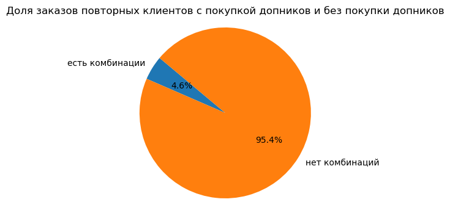

```python
# Шаг 2: Группируем по if_combo и считаем количество уникальных заказов
msc_old_order_counts = msc_old_clients.groupby('if_combo')['order_id'].nunique().reset_index()
msc_old_order_counts.columns = ['if_combo', 'unique_order_count']

# Шаг 3: Общая сумма уникальных заказов
total_unique_orders = msc_old_clients['order_id'].nunique()

# Шаг 4: Вычисляем долю для каждой категории
msc_old_order_counts['proportion'] = msc_old_order_counts['unique_order_count'] / total_unique_orders

# Шаг 1: Настройка круговой диаграммы
plt.figure(figsize=(6, 4))
plt.pie(msc_old_order_counts['proportion'], labels=msc_old_order_counts['if_combo'], autopct='%1.1f%%', startangle=140)

# Шаг 2: Добавление заголовка
plt.title('Доля заказов повторных клиентов с покупкой допников и без покупки допников в Москве')

# Шаг 3: Отображение диаграммы
plt.axis('equal')  # Создает круговую диаграмму
plt.show()
```

```python
# Фильтруем данные по 'category' == "рационы"
msc_rat_clients = msc_old_clients[msc_old_clients['category'] == 'рационы'].copy()

# Группируем по 'name' и 'if_combo', чтобы сосчитать уникальных пользователей
msc_rat_combo_counts = msc_rat_clients.groupby(['name', 'if_combo'])['user_id'].nunique().reset_index()

# Пивотируем таблицу для лучшей видимости соотношений
msc_rat_combo_pivot = msc_rat_combo_counts.pivot(index='name', columns='if_combo', values='user_id').fillna(0)

# Рассчитываем общее количество пользователей с комбинациями и без
msc_rat_combo_pivot['total'] = msc_rat_combo_pivot.sum(axis=1)

# Рассчитываем соотношение
msc_rat_combo_pivot['ratio_with_combo'] = msc_rat_combo_pivot.get('есть комбинации', 0) / msc_rat_combo_pivot['total'] * 100
msc_rat_combo_pivot['ratio_without_combo'] = msc_rat_combo_pivot.get('нет комбинаций', 0) / msc_rat_combo_pivot['total'] * 100

# Смотрим результат
msc_rat_combo_pivot[['есть комбинации', 'нет комбинаций', 'total', 'ratio_with_combo', 'ratio_without_combo']]
```

| if_combo name | есть комбинации | нет комбинаций | total | ratio_with_combo | ratio_without_combo |
| --- | --- | --- | --- | --- | --- |
| базовый | 1.0 | 92.0 | 93.0 | 1.075269 | 98.924731 |
| баланс | 4.0 | 114.0 | 118.0 | 3.389831 | 96.610169 |
| ввг | 7.0 | 89.0 | 96.0 | 7.291667 | 92.708333 |
| зц | 1.0 | 16.0 | 17.0 | 5.882353 | 94.117647 |
| комбо | 0.0 | 20.0 | 20.0 | 0.000000 | 100.000000 |
| семейный | 2.0 | 34.0 | 36.0 | 5.555556 | 94.444444 |
| супер | 6.0 | 55.0 | 61.0 | 9.836066 | 90.163934 |

Создание датафрейма с новыми клиентами и их комбинациями для Питера

```python
spb_new_clients = data.query('city == "saint_petersburg" & order_flag == 0')

# Шаг 1: Группируем данные по user_id и категории
sbp_clients_categories = spb_new_clients.groupby('user_id')['category'].nunique().reset_index()

# Шаг 2: Добавляем новый столбец для флагов
def set_combo_flag(row):
    if row['category'] > 1:
        return "есть комбинации"  # Если более одной категории
    else:
        return "нет комбинаций"  # Если одна категория

sbp_clients_categories['if_combo'] = sbp_clients_categories.apply(set_combo_flag, axis=1)

# Шаг 3: Объединяем с оригинальным DataFrame
spb_new_clients = spb_new_clients.merge(sbp_clients_categories[['user_id', 'if_combo']], on='user_id', how='left')

# Теперь spb_new_clients содержит новый столбец if_combo
spb_new_clients = spb_new_clients.sort_values(by='order_id')
spb_new_clients.tail(10)
```

|  | item_id | order_id | user_id | order_date | name | sum | days | city | order_flag | category | if_combo |
| --- | --- | --- | --- | --- | --- | --- | --- | --- | --- | --- | --- |
| 132 | 157123 | 136099 | 228975 | 2024-11-26 | комбо | 35880 | 30 | saint_petersburg | 0 | рационы | нет комбинаций |
| 159 | 157153 | 136124 | 946778 | 2024-11-26 | семейный | 6084 | 4 | saint_petersburg | 0 | рационы | нет комбинаций |
| 160 | 157160 | 136131 | 1134789 | 2024-11-26 | семейный | 6084 | 4 | saint_petersburg | 0 | рационы | нет комбинаций |
| 75 | 157221 | 136182 | 166581 | 2024-11-27 | ввг | 25110 | 30 | saint_petersburg | 0 | рационы | нет комбинаций |
| 133 | 157241 | 136202 | 1091888 | 2024-11-27 | комбо | 8340 | 6 | saint_petersburg | 0 | рационы | нет комбинаций |
| 106 | 157245 | 136204 | 938321 | 2024-11-27 | ввг | 37260 | 30 | saint_petersburg | 0 | рационы | нет комбинаций |
| 97 | 157244 | 136204 | 938321 | 2024-11-27 | ввг | 31740 | 30 | saint_petersburg | 0 | рационы | нет комбинаций |
| 176 | 157262 | 136220 | 893380 | 2024-11-27 | супер | 1324 | 2 | saint_petersburg | 0 | рационы | нет комбинаций |
| 60 | 157284 | 136236 | 1134930 | 2024-11-27 | ввг | 1554 | 2 | saint_petersburg | 0 | рационы | нет комбинаций |
| 136 | 157299 | 136250 | 491675 | 2024-11-27 | комбо | 9540 | 6 | saint_petersburg | 0 | рационы | нет комбинаций |

Соотношение комбинаций новых клиентов Питер

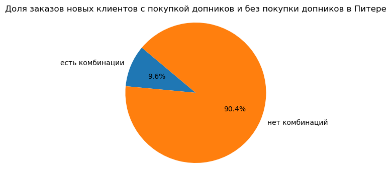

```python
# Шаг 2: Группируем по if_combo и считаем количество уникальных заказов
spb_new_order_counts = spb_new_clients.groupby('if_combo')['order_id'].nunique().reset_index()
spb_new_order_counts.columns = ['if_combo', 'unique_order_count']

# Шаг 3: Общая сумма уникальных заказов
total_unique_orders = spb_new_clients['order_id'].nunique()

# Шаг 4: Вычисляем долю для каждой категории
spb_new_order_counts['proportion'] = spb_new_order_counts['unique_order_count'] / total_unique_orders

# Шаг 1: Настройка круговой диаграммы
plt.figure(figsize=(6, 4))
plt.pie(spb_new_order_counts['proportion'], labels=spb_new_order_counts['if_combo'], autopct='%1.1f%%', startangle=140)

# Шаг 2: Добавление заголовка
plt.title('Доля заказов новых клиентов с покупкой допников и без покупки допников в Питере')

# Шаг 3: Отображение диаграммы
plt.axis('equal')  # Создает круговую диаграмму
plt.show()
```

```python
# Фильтруем данные по 'category' == "рационы"
msc_rat_clients = spb_new_clients[spb_new_clients['category'] == 'рационы'].copy()

# Группируем по 'name' и 'if_combo', чтобы сосчитать уникальных пользователей
msc_rat_combo_counts = msc_rat_clients.groupby(['name', 'if_combo'])['user_id'].nunique().reset_index()

# Пивотируем таблицу для лучшей видимости соотношений
msc_rat_combo_pivot = msc_rat_combo_counts.pivot(index='name', columns='if_combo', values='user_id').fillna(0)

# Рассчитываем общее количество пользователей с комбинациями и без
msc_rat_combo_pivot['total'] = msc_rat_combo_pivot.sum(axis=1)

# Рассчитываем соотношение
msc_rat_combo_pivot['ratio_with_combo'] = msc_rat_combo_pivot.get('есть комбинации', 0) / msc_rat_combo_pivot['total'] * 100
msc_rat_combo_pivot['ratio_without_combo'] = msc_rat_combo_pivot.get('нет комбинаций', 0) / msc_rat_combo_pivot['total'] * 100

# Смотрим результат
msc_rat_combo_pivot[['есть комбинации', 'нет комбинаций', 'total', 'ratio_with_combo', 'ratio_without_combo']]
```

| if_combo name | есть комбинации | нет комбинаций | total | ratio_with_combo | ratio_without_combo |
| --- | --- | --- | --- | --- | --- |
| баланс | 0.0 | 27.0 | 27.0 | 0.000000 | 100.000000 |
| ввг | 11.0 | 63.0 | 74.0 | 14.864865 | 85.135135 |
| зц | 0.0 | 1.0 | 1.0 | 0.000000 | 100.000000 |
| комбо | 1.0 | 25.0 | 26.0 | 3.846154 | 96.153846 |
| семейный | 2.0 | 15.0 | 17.0 | 11.764706 | 88.235294 |
| супер | 2.0 | 11.0 | 13.0 | 15.384615 | 84.615385 |

Создание датафрейма с повторными клиентами и их комбинациями для Питера

```python
spb_old_clients = data.query('city == "saint_petersburg" & order_flag == 1')

# Шаг 1: Группируем данные по user_id и категории
sbp_clients_categories = spb_old_clients.groupby('user_id')['category'].nunique().reset_index()

# Шаг 2: Добавляем новый столбец для флагов
def set_combo_flag(row):
    if row['category'] > 1:
        return "есть комбинации"  # Если более одной категории
    else:
        return "нет комбинаций"  # Если одна категория

sbp_clients_categories['if_combo'] = sbp_clients_categories.apply(set_combo_flag, axis=1)

# Шаг 3: Объединяем с оригинальным DataFrame
spb_old_clients = spb_old_clients.merge(sbp_clients_categories[['user_id', 'if_combo']], on='user_id', how='left')

# Теперь spb_old_clients содержит новый столбец if_combo
spb_old_clients = spb_old_clients.sort_values(by='order_id')
spb_old_clients.tail(10)
```

|  | item_id | order_id | user_id | order_date | name | sum | days | city | order_flag | category | if_combo |
| --- | --- | --- | --- | --- | --- | --- | --- | --- | --- | --- | --- |
| 7 | 157112 | 136088 | 1103121 | 2024-11-25 | овощные нарезки | 1200 | 8 | saint_petersburg | 1 | сеты | есть комбинации |
| 43 | 157124 | 136100 | 1104512 | 2024-11-26 | ввг | 1554 | 2 | saint_petersburg | 1 | рационы | нет комбинаций |
| 120 | 157134 | 136110 | 922915 | 2024-11-26 | супер | 1890 | 2 | saint_petersburg | 1 | рационы | нет комбинаций |
| 103 | 157168 | 136138 | 1125185 | 2024-11-26 | семейный | 2700 | 2 | saint_petersburg | 1 | рационы | есть комбинации |
| 69 | 157200 | 136165 | 1072643 | 2024-11-26 | ввг | 2300 | 2 | saint_petersburg | 1 | рационы | нет комбинаций |
| 44 | 157229 | 136190 | 1104512 | 2024-11-27 | ввг | 1554 | 2 | saint_petersburg | 1 | рационы | нет комбинаций |
| 121 | 157257 | 136216 | 1061133 | 2024-11-27 | супер | 1890 | 2 | saint_petersburg | 1 | рационы | нет комбинаций |
| 122 | 157277 | 136232 | 1124503 | 2024-11-27 | супер | 1890 | 2 | saint_petersburg | 1 | рационы | нет комбинаций |
| 91 | 157285 | 136237 | 1120105 | 2024-11-27 | комбо | 10136 | 8 | saint_petersburg | 1 | рационы | нет комбинаций |
| 87 | 157305 | 136255 | 1036042 | 2024-11-27 | комбо | 8100 | 6 | saint_petersburg | 1 | рационы | нет комбинаций |

Соотношение комбинаций повторных клиентов Питер

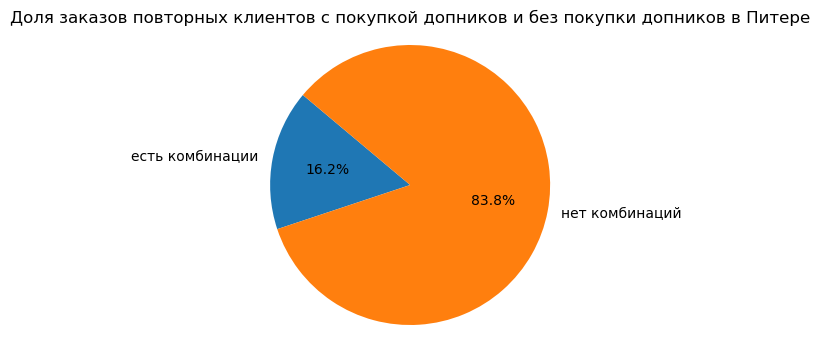

```python
# Шаг 2: Группируем по if_combo и считаем количество уникальных заказов
spb_old_order_counts = spb_old_clients.groupby('if_combo')['order_id'].nunique().reset_index()
spb_old_order_counts.columns = ['if_combo', 'unique_order_count']

# Шаг 3: Общая сумма уникальных заказов
total_unique_orders = spb_old_clients['order_id'].nunique()

# Шаг 4: Вычисляем долю для каждой категории
spb_old_order_counts['proportion'] = spb_old_order_counts['unique_order_count'] / total_unique_orders

# Шаг 1: Настройка круговой диаграммы
plt.figure(figsize=(6, 4))
plt.pie(spb_old_order_counts['proportion'], labels=spb_old_order_counts['if_combo'], autopct='%1.1f%%', startangle=140)

# Шаг 2: Добавление заголовка
plt.title('Доля заказов повторных клиентов с покупкой допников и без покупки допников в Питере')

# Шаг 3: Отображение диаграммы
plt.axis('equal')  # Создает круговую диаграмму
plt.show()
```

```python
# Фильтруем данные по 'category' == "рационы"
msc_rat_clients = spb_old_clients[spb_old_clients['category'] == 'рационы'].copy()

# Группируем по 'name' и 'if_combo', чтобы сосчитать уникальных пользователей
msc_rat_combo_counts = msc_rat_clients.groupby(['name', 'if_combo'])['user_id'].nunique().reset_index()

# Пивотируем таблицу для лучшей видимости соотношений
msc_rat_combo_pivot = msc_rat_combo_counts.pivot(index='name', columns='if_combo', values='user_id').fillna(0)

# Рассчитываем общее количество пользователей с комбинациями и без
msc_rat_combo_pivot['total'] = msc_rat_combo_pivot.sum(axis=1)

# Рассчитываем соотношение
msc_rat_combo_pivot['ratio_with_combo'] = msc_rat_combo_pivot.get('есть комбинации', 0) / msc_rat_combo_pivot['total'] * 100
msc_rat_combo_pivot['ratio_without_combo'] = msc_rat_combo_pivot.get('нет комбинаций', 0) / msc_rat_combo_pivot['total'] * 100

# Смотрим результат
msc_rat_combo_pivot[['есть комбинации', 'нет комбинаций', 'total', 'ratio_with_combo', 'ratio_without_combo']]
```

| if_combo name | есть комбинации | нет комбинаций | total | ratio_with_combo | ratio_without_combo |
| --- | --- | --- | --- | --- | --- |
| баланс | 1.0 | 6.0 | 7.0 | 14.285714 | 85.714286 |
| ввг | 5.0 | 19.0 | 24.0 | 20.833333 | 79.166667 |
| зц | 0.0 | 1.0 | 1.0 | 0.000000 | 100.000000 |
| комбо | 0.0 | 10.0 | 10.0 | 0.000000 | 100.000000 |
| семейный | 2.0 | 2.0 | 4.0 | 50.000000 | 50.000000 |
| супер | 1.0 | 11.0 | 12.0 | 8.333333 | 91.666667 |

Для Москвы и Питера создали датафреймы без Баланса, с уникальными заказами, имеющими сеты/допродажи

```python
msc_no_balance_data = data.query('name != "баланс" & city == "moscow"')
spb_no_balance_data = data.query('name != "баланс" & city == "saint_petersburg"')
```

```python
# Группировка и фильтрация
msc_filtered = (msc_no_balance_data.groupby(['order_id', 'order_date'])['category']
            .nunique()
            .reset_index(name='unique_categories_count'))

# Оставляем только те записи, где количество уникальных категорий больше 1
msc_filtered = msc_filtered[msc_filtered['unique_categories_count'] > 1]

# Объединение с исходным DataFrame для получения нужных строк
msc_final_data = pd.merge(msc_no_balance_data, msc_filtered[['order_id', 'order_date']],
                         on=['order_id', 'order_date'])

# Вывод финального результата
msc_final_data
```

|  | item_id | order_id | user_id | order_date | name | sum | days | city | order_flag | category |
| --- | --- | --- | --- | --- | --- | --- | --- | --- | --- | --- |
| 0 | 154454 | 134063 | 1082363 | 2024-11-05 | базовый | 4140 | 6 | moscow | 0 | рационы |
| 1 | 154455 | 134063 | 1082363 | 2024-11-05 | соки из вкусвилл | 900 | 6 | moscow | 0 | сеты |
| 2 | 155187 | 134612 | 888318 | 2024-11-11 | базовый | 8355 | 15 | moscow | 0 | рационы |
| 3 | 155188 | 134612 | 888318 | 2024-11-11 | овощные нарезки | 1920 | 15 | moscow | 0 | сеты |
| 4 | 155189 | 134612 | 888318 | 2024-11-11 | фруктовые нарезки | 2550 | 15 | moscow | 0 | сеты |
| ... | ... | ... | ... | ... | ... | ... | ... | ... | ... | ... |
| 118 | 155491 | 134856 | 1118979 | 2024-11-14 | семейный | 10140 | 6 | moscow | 1 | рационы |
| 119 | 155492 | 134856 | 1118979 | 2024-11-14 | чиабатта к супу | 174 | 6 | moscow | 1 | сеты |
| 120 | 155493 | 134856 | 1118979 | 2024-11-14 | чиабатта к супу | 174 | 6 | moscow | 1 | сеты |
| 121 | 157002 | 135996 | 273946 | 2024-11-24 | семейный | 3380 | 2 | moscow | 0 | рационы |
| 122 | 157003 | 135996 | 273946 | 2024-11-24 | смузи из вкусвилл | 260 | 2 | moscow | 0 | сеты |

123 rows × 10 columns

Создаем флаг "есть семья/нет семьи" для Москвы

```python
msc_final_data['value_per_day'] = msc_final_data['sum'] / msc_final_data['days']
# Добавляем новый столбец 'has_family' с условиями
msc_final_data['has_family'] = msc_final_data['value_per_day'].apply(
    lambda x: 0 if x < 1242 else (1 if x >= 1187 else None)
)

# Выводим результат для проверки
msc_final_data
```

|  | item_id | order_id | user_id | order_date | name | sum | days | city | order_flag | category | value_per_day | has_family |
| --- | --- | --- | --- | --- | --- | --- | --- | --- | --- | --- | --- | --- |
| 0 | 154454 | 134063 | 1082363 | 2024-11-05 | базовый | 4140 | 6 | moscow | 0 | рационы | 690.0 | 0 |
| 1 | 154455 | 134063 | 1082363 | 2024-11-05 | соки из вкусвилл | 900 | 6 | moscow | 0 | сеты | 150.0 | 0 |
| 2 | 155187 | 134612 | 888318 | 2024-11-11 | базовый | 8355 | 15 | moscow | 0 | рационы | 557.0 | 0 |
| 3 | 155188 | 134612 | 888318 | 2024-11-11 | овощные нарезки | 1920 | 15 | moscow | 0 | сеты | 128.0 | 0 |
| 4 | 155189 | 134612 | 888318 | 2024-11-11 | фруктовые нарезки | 2550 | 15 | moscow | 0 | сеты | 170.0 | 0 |
| ... | ... | ... | ... | ... | ... | ... | ... | ... | ... | ... | ... | ... |
| 118 | 155491 | 134856 | 1118979 | 2024-11-14 | семейный | 10140 | 6 | moscow | 1 | рационы | 1690.0 | 1 |
| 119 | 155492 | 134856 | 1118979 | 2024-11-14 | чиабатта к супу | 174 | 6 | moscow | 1 | сеты | 29.0 | 0 |
| 120 | 155493 | 134856 | 1118979 | 2024-11-14 | чиабатта к супу | 174 | 6 | moscow | 1 | сеты | 29.0 | 0 |
| 121 | 157002 | 135996 | 273946 | 2024-11-24 | семейный | 3380 | 2 | moscow | 0 | рационы | 1690.0 | 1 |
| 122 | 157003 | 135996 | 273946 | 2024-11-24 | смузи из вкусвилл | 260 | 2 | moscow | 0 | сеты | 130.0 | 0 |

123 rows × 12 columns

Смотрим распределение клиентов Москвы "с семьей" и "без семьи"

```python
# Подсчитываем уникальные order_id для has_family == 0 и has_family == 1
unique_orders_0 = msc_final_data[msc_final_data['has_family'] == 0]['order_id'].nunique()
unique_orders_1 = msc_final_data[msc_final_data['has_family'] == 1]['order_id'].nunique()

# Общее количество уникальных order_id
total_unique_orders = unique_orders_0 + unique_orders_1

# Вычисляем процентное соотношение
percentage_0 = (unique_orders_0 / total_unique_orders) * 100 if total_unique_orders > 0 else 0
percentage_1 = (unique_orders_1 / total_unique_orders) * 100 if total_unique_orders > 0 else 0

# Выводим результаты
print(f"Уникальные заказы без семьи: {unique_orders_0}")
print(f"Уникальные заказы с семьей: {unique_orders_1}")
print(f"Процент заказов со без семьи: {percentage_0:.2f}%")
print(f"Процент заказов с семьей: {percentage_1:.2f}%")
```

```
Уникальные заказы без семьи: 54
Уникальные заказы с семьей: 16
Процент заказов со без семьи: 77.14%
Процент заказов с семьей: 22.86%
```

Тепрерь то же самое для Питера

```python
# Группировка и фильтрация
spb_filtered = (spb_no_balance_data.groupby(['order_id', 'order_date'])['category']
            .nunique()
            .reset_index(name='unique_categories_count'))

# Оставляем только те записи, где количество уникальных категорий больше 1
spb_filtered = spb_filtered[spb_filtered['unique_categories_count'] > 1]

# Объединение с исходным DataFrame для получения нужных строк
spb_final_data = pd.merge(spb_no_balance_data, spb_filtered[['order_id', 'order_date']],
                         on=['order_id', 'order_date'])
```

```python
spb_final_data['value_per_day'] = spb_final_data['sum'] / spb_final_data['days']
# Добавляем новый столбец 'has_family' с условиями
spb_final_data['has_family'] = spb_final_data['value_per_day'].apply(
    lambda x: 0 if x < 1242 else (1 if x >= 1187 else None)
)
```

```python
# Подсчитываем уникальные order_id для has_family == 0 и has_family == 1
unique_orders_0 = spb_final_data[spb_final_data['has_family'] == 0]['order_id'].nunique()
unique_orders_1 = spb_final_data[spb_final_data['has_family'] == 1]['order_id'].nunique()

# Общее количество уникальных order_id
total_unique_orders = unique_orders_0 + unique_orders_1

# Вычисляем процентное соотношение
percentage_0 = (unique_orders_0 / total_unique_orders) * 100 if total_unique_orders > 0 else 0
percentage_1 = (unique_orders_1 / total_unique_orders) * 100 if total_unique_orders > 0 else 0

# Выводим результаты
print(f"Уникальные заказы без семьи: {unique_orders_0}")
print(f"Уникальные заказы с семьей: {unique_orders_1}")
print(f"Процент заказов со без семьи: {percentage_0:.2f}%")
print(f"Процент заказов с семьей: {percentage_1:.2f}%")
```

```
Уникальные заказы без семьи: 26
Уникальные заказы с семьей: 12
Процент заказов со без семьи: 68.42%
Процент заказов с семьей: 31.58%
```

### Сравнить среднее количество дней питания всего и среднее количество дней питания, заказывающих сеты и допродажи.

Создали датафрейм с фильтрацией является заказ комбинацией или нет.

```python
combined_data = data

# Шаг 1: Группируем данные по user_id и категории
combined_clients_categories = combined_data.groupby('user_id')['category'].nunique().reset_index()

# Шаг 2: Добавляем новый столбец для флагов
def set_combo_flag(row):
    if row['category'] > 1:
        return "есть комбинации"  # Если более одной категории
    else:
        return "нет комбинаций"  # Если одна категория

combined_clients_categories['if_combo'] = combined_clients_categories.apply(set_combo_flag, axis=1)

# Шаг 3: Объединяем с оригинальным DataFrame
combined_data = combined_data.merge(combined_clients_categories[['user_id', 'if_combo']], on='user_id', how='left')

# Теперь combined_data содержит новый столбец if_combo
combined_data = combined_data.sort_values(by='order_id')
combined_data.tail(10)
```

|  | item_id | order_id | user_id | order_date | name | sum | days | city | order_flag | category | if_combo |
| --- | --- | --- | --- | --- | --- | --- | --- | --- | --- | --- | --- |
| 684 | 157297 | 136248 | 374699 | 2024-11-27 | баланс | 28416 | 16 | moscow | 0 | рационы | нет комбинаций |
| 411 | 157298 | 136249 | 1134952 | 2024-11-27 | базовый | 3150 | 3 | moscow | 0 | рационы | нет комбинаций |
| 2217 | 157299 | 136250 | 491675 | 2024-11-27 | комбо | 9540 | 6 | saint_petersburg | 0 | рационы | нет комбинаций |
| 1704 | 157300 | 136251 | 807284 | 2024-11-27 | супер | 2850 | 3 | moscow | 0 | рационы | нет комбинаций |
| 1705 | 157301 | 136252 | 640038 | 2024-11-27 | супер | 2988 | 3 | moscow | 0 | рационы | есть комбинации |
| 1973 | 157302 | 136252 | 640038 | 2024-11-27 | смузи из вкусвилл | 390 | 3 | moscow | 0 | сеты | есть комбинации |
| 1177 | 157303 | 136253 | 411881 | 2024-11-27 | ввг | 10896 | 8 | moscow | 1 | рационы | нет комбинаций |
| 1026 | 157304 | 136254 | 1065723 | 2024-11-27 | ввг | 25950 | 30 | moscow | 0 | рационы | нет комбинаций |
| 2198 | 157305 | 136255 | 1036042 | 2024-11-27 | комбо | 8100 | 6 | saint_petersburg | 1 | рационы | нет комбинаций |
| 153 | 157307 | 136257 | 944384 | 2024-11-27 | базовый | 4140 | 6 | moscow | 0 | рационы | нет комбинаций |

```python
msc_no_combination_data = combined_data.query('if_combo == "нет комбинаций" & city == "moscow"')
msc_has_combination_data = combined_data.query('if_combo == "есть комбинации" & city == "moscow"')
spb_no_combination_data = combined_data.query('if_combo == "нет комбинаций" & city == "saint_petersburg"')
spb_has_combination_data = combined_data.query('if_combo == "есть комбинации" & city == "saint_petersburg"')
```

Среднее количество дней питания в день для Москвы для клиентов без комбинаций

```python
msc_no_combination_data['days'].mean().round()
```

```
9.0
```

Среднее количество дней питания в день для Москвы для клиентов с комбинациями

```python
msc_has_combination_data['days'].mean().round()
```

```
6.0
```

Среднее количество дней питания в день для Питера для клиентов без комбинаций

```python
spb_no_combination_data['days'].mean().round()
```

```
9.0
```

Среднее количество дней питания в день для Питера для клиентов с комбинациясм

```python
spb_has_combination_data['days'].mean().round()
```

```
5.0
```

**Выводы по исследованию:**

Из сетов в Москве и Питере лучше всего продаются соки. Допродажи малочисленны для анализа.

В Москве 99,61% выручки приходится на рационы, 0,37% на сеты и 0,01% для допроджи В Питере 99,06% выручки приходится на рационы, 0,92% на сеты, 0.02% на допродажи

В Москве 95,17% всех заказов приходится на рационы, 3,74% на сеты, 1,09% на допродажи В Питере 88,89% всех заказов приходится на рационы, 9,48% на сеты, 1,63% на допродажи

Средний чек клиентов с сетами и доптоварами для Москвы составляет 7280 рублей, без Баланса 6274 рубля. Для Питера 5787 рублей, без Баланса 4954 рублей.

В Москве лидером комбинации по продажам составляет рацион ВВГ + соки из ВкусВилл, далее Смузи из ВкусВилл + супер В Питере лидером комбинации по продажам составляет рацион ВВГ + соки из ВкусВилл

В Москве соотношение заказов с комбинациями и без комбинаций для новых клиентов равно 4% к 95% В Москве соотношение заказов с комбинациями и без комбинаций для повторных клиентов равно 4% к 95%

В Питере соотношение заказов с комбинациями и без комбинаций для новых клиентов равно 9,6% к 90,3% В Питере соотношение заказов с комбинациями и без комбинаций для повторных клиентов равно 16% к 83%

Для Москвы клиенты "с семьей" и "без семьи" распределяются следующим образом: Уникальные заказы без семьи: 54 Уникальные заказы с семьей: 16 Процент заказов со без семьи: 77.14% Процент заказов с семьей: 22.86%

**Общие выводы:**

**1. Оценить популярность доптоваров.**

В Москве соотношение заказов с комбинациями и без комбинаций для новых клиентов 4% к 95%, для повторных 4% к 95%. В Питере для новых 9,6% к 90,3%, для повторных 16% к 83%. (тут изначально разный объем аудитории. Поэтому между собой сравнивать эти показатели неправильно. Если Питер будет расти у него будут тоже усредненные близкие друг другу значения).

Самая популярная комбинация ВВГ + соки в обоих городах.

**2. Оценить ЦА покупающих доптовары.**

Клиенты с низким дневным чеком, которых мы определили как одиночек, для Питера составляют 68%, против семейных 31%; для Москвы без семьи 77% против 22% семейных.